# Sahadeo_Assignment8_MPG

Rishi Sahadeo

2025-10-27

1. Create a scatterplot of the data from the calibration runs, plotting the MPG on the vertical axis and speed on the horizontal axis (be sure to properly label your plot). Does there appear to be an association between the speed the bike is driven at and the MPG? If so, explain what the nature of the relationship seems to be.

```r
# load the data
data <- read.table("C:\\Users\\supaq\\OneDrive\\Desktop\\Rutgers Courses\\Regression Methods - Fall 2025\\mpg-1.txt", header = TRUE)

# cols
names(data) <- c("speed", "mpg")

# view data
head(data)
```

```
##        speed      mpg
## 1  79.373049 36.18784
## 2   1.080288 13.39034
## 3 111.317162 20.59088
## 4  54.263529 39.27212
## 5 106.904475 27.97295
## 6  13.940522 26.05444
```

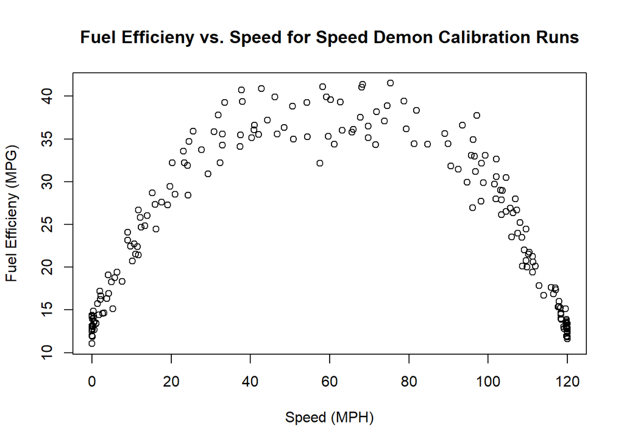

```r
# scatterplot
plot(
  x = data$speed,
  y = data$mpg,
  xlab = "Speed (MPH)",
  ylab = "Fuel Efficieny (MPG)",
  main = "Fuel Efficieny vs. Speed for Speed Demon Calibration Runs"
)
```

Overall, the shows that the motorcycle achieves optimal efficiency at mid-range speeds and becomes less efficient when driving too slowly or too fast.

2. The National Highway Traffic Safety Administration (NHTSA) requires all vehicles marketed in the US to provide ranges for what the mean MPG is at a variety of speeds. Treating MPG as the response variable and speed as the explanatory variable, are enough of the model assumptions satisfied in order to fit a polynomial model to this data towards the prior purpose? If not, explain what must be done to address the deviations from the needed model assumptions (if necessary).

Treating MPG as the response variable and speed MPH as the explanatory variable, the data satisfy most of the regression model assumptions needed to fit a polynomial model.

The assumptions required for regression are adequately met to fit a polynomial model. A quadratic polynomial will be the most appropriate starting form for capturing the observed curvature between speed and fuel efficiency.

3. After addressing any issues in part 2, fit a polynomial model to the data. Clearly explain the process with which you went about arriving at the order of the polynomial model you fit (you will need to fit several polynomial models and compare them). Explicitly write out the estimated model equation for the polynomial model you decided upon (on the transformed scales if data transformations were needed).

```r
# model fits
model1 <- lm(mpg ~ speed, data = data)
model2 <- lm(mpg ~ poly(speed, 2, raw = TRUE), data = data)
model3 <- lm(mpg ~ poly(speed, 3, raw = TRUE), data = data)
model4 <- lm(mpg ~ poly(speed, 4, raw = TRUE), data = data)

summary(model1)
```

```
##
## Call:
## lm(formula = mpg ~ speed, data = data)
##
## Residuals:
##      Min       1Q   Median       3Q      Max
## -13.4827 -10.1762  -0.2346   9.6693  16.8106
##
## Coefficients:
##             Estimate Std. Error t value Pr(>|t|)
## (Intercept) 24.53770    1.14559  21.419   <2e-16 ***
## speed        0.00216    0.01498   0.144    0.885
## ---
## Signif. codes:  0 '***' 0.001 '**' 0.01 '*' 0.05 '.' 0.1 ' ' 1
##
## Residual standard error: 9.7 on 198 degrees of freedom
## Multiple R-squared:  0.0001051,  Adjusted R-squared:  -0.004945
## F-statistic: 0.02081 on 1 and 198 DF,  p-value: 0.8855
```

```r
summary(model2)
```

```
##
## Call:
## lm(formula = mpg ~ poly(speed, 2, raw = TRUE), data = data)
##
## Residuals:
##     Min      1Q  Median      3Q     Max
## -7.8072 -1.3086 -0.3678  1.2513  7.7792
##
## Coefficients:
##                               Estimate Std. Error t value Pr(>|t|)
## (Intercept)                 13.6508907  0.3193404   42.75   <2e-16 ***
## poly(speed, 2, raw = TRUE)1  0.8770302  0.0150241   58.38   <2e-16 ***
## poly(speed, 2, raw = TRUE)2 -0.0073000  0.0001221  -59.81   <2e-16 ***
## ---
## Signif. codes:  0 '***' 0.001 '**' 0.01 '*' 0.05 '.' 0.1 ' ' 1
##
## Residual standard error: 2.222 on 197 degrees of freedom
## Multiple R-squared:  0.9478, Adjusted R-squared:  0.9473
## F-statistic:  1789 on 2 and 197 DF,  p-value: < 2.2e-16
```

```r
summary(model3)
```

```
##
## Call:
## lm(formula = mpg ~ poly(speed, 3, raw = TRUE), data = data)
##
## Residuals:
##     Min      1Q  Median      3Q     Max
## -7.7826 -1.3116 -0.2895  1.3485  7.5638
##
## Coefficients:
##                               Estimate Std. Error t value Pr(>|t|)
## (Intercept)                  1.381e+01  3.571e-01  38.665   <2e-16 ***
## poly(speed, 3, raw = TRUE)1  8.468e-01  3.466e-02  24.433   <2e-16 ***
## poly(speed, 3, raw = TRUE)2 -6.605e-03  7.279e-04  -9.074   <2e-16 ***
## poly(speed, 3, raw = TRUE)3 -3.882e-06  4.009e-06  -0.968    0.334
## ---
## Signif. codes:  0 '***' 0.001 '**' 0.01 '*' 0.05 '.' 0.1 ' ' 1
##
## Residual standard error: 2.222 on 196 degrees of freedom
## Multiple R-squared:  0.9481, Adjusted R-squared:  0.9473
## F-statistic:  1193 on 3 and 196 DF,  p-value: < 2.2e-16
```

```r
summary(model4)
```

```
##
## Call:
## lm(formula = mpg ~ poly(speed, 4, raw = TRUE), data = data)
##
## Residuals:
##     Min      1Q  Median      3Q     Max
## -6.0369 -1.1029 -0.0146  1.1085  6.4419
##
## Coefficients:
##                               Estimate Std. Error t value Pr(>|t|)
## (Intercept)                  1.277e+01  3.327e-01  38.388  < 2e-16 ***
## poly(speed, 4, raw = TRUE)1  1.232e+00  5.541e-02  22.231  < 2e-16 ***
## poly(speed, 4, raw = TRUE)2 -2.324e-02  2.111e-03 -11.009  < 2e-16 ***
## poly(speed, 4, raw = TRUE)3  2.179e-04  2.709e-05   8.043 8.32e-14 ***
## poly(speed, 4, raw = TRUE)4 -9.162e-07  1.110e-07  -8.254 2.27e-14 ***
## ---
## Signif. codes:  0 '***' 0.001 '**' 0.01 '*' 0.05 '.' 0.1 ' ' 1
##
## Residual standard error: 1.918 on 195 degrees of freedom
## Multiple R-squared:  0.9615, Adjusted R-squared:  0.9607
## F-statistic:  1218 on 4 and 195 DF,  p-value: < 2.2e-16
```

The linear model explains almost nothing.  
The quadratic model improves fit as R^2 = 0.9478.  
The cubic model adds no meaningful gain but has a p-val of 0.334.  
The quartic model improves R^2 to 0.9615 and all terms are significant with a low p-value. An anova test can check if the improvement is significant.

```r
anova(model2, model4)
```

```
## Analysis of Variance Table
##
## Model 1: mpg ~ poly(speed, 2, raw = TRUE)
## Model 2: mpg ~ poly(speed, 4, raw = TRUE)
##   Res.Df    RSS Df Sum of Sq      F    Pr(>F)
## 1    197 972.41
## 2    195 717.21  2    255.21 34.694 1.288e-13 ***
## ---
## Signif. codes:  0 '***' 0.001 '**' 0.01 '*' 0.05 '.' 0.1 ' ' 1
```

H_0: The quartic model adds no improvement, Beta_3 = Beta_4 = 0  
H_a: Atleast one of Beta_3 or Beta_4 improves the fit.

Since p-value <0.001, we reject H_0.  
The quartic model is a statistically significant improvement from the quadratic.

Polynomial regression models, linear, quadratic, cubic and quartic were fit with speed as the explanatory variable and MPG as the response. The linear model performed poorly with R^2 = 0.0001 and pval = 0.8855, while the quadratic model improved fit where R^2 increased to 0.9478. The cubic model provided no significant improvement and had pval = 0.334. The quartic model produced the highest R^2 = 0.9615 and adjusted R^2 = 0.9607, with all terms significant (pval < 0.001).

An ANOVA comparison between quadratic and quartic models (F = 34.7, pval < 0.001) confirmed that the additional terms improved model fit. The quartic model was the most appropriate representation of the relationships:

- MPG_hat = 12.77 + 1.232(speed) - 0.02324(speed)^2 + 0.0002179(speed)^3 - 0.0000009162(speed)^4

4. On a scatter plot depicting the MPG on the vertical axis and speed on the horizontal axis (on their original, untransformed measurement scales), overlay the estimated model on the plot (in the event you transformed any of your variables, this may necessitate back transforming the polynomial model that was constructed on the transformed data)

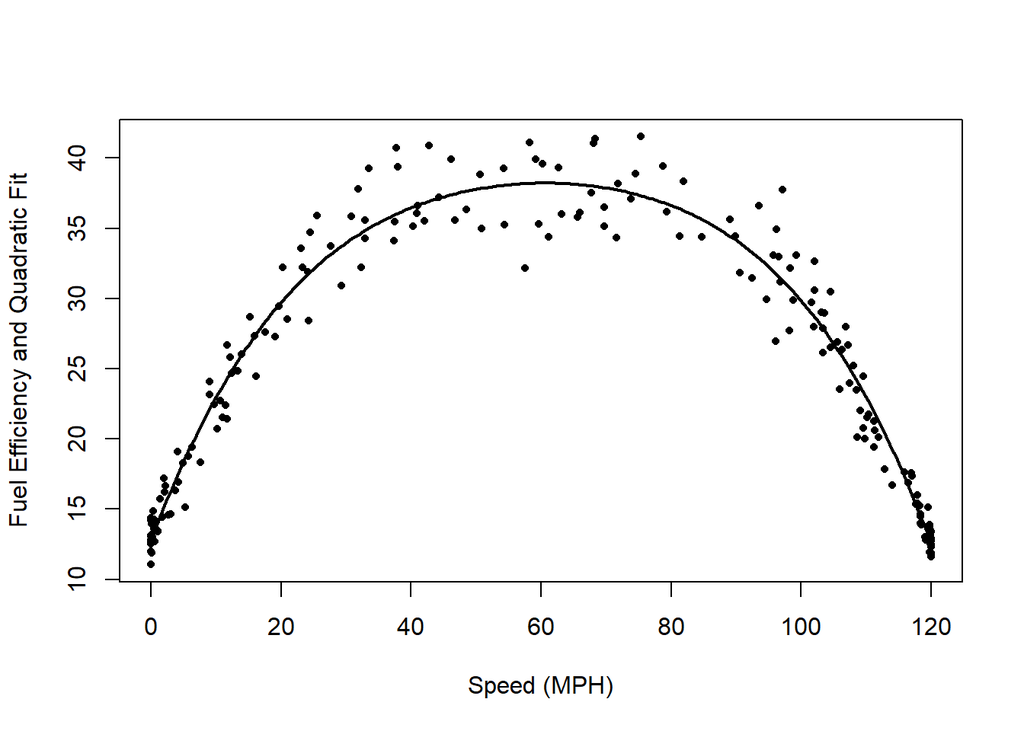

```r
# grid of speed
speed_data <- seq(
  from = min(data$speed),
  to = max(data$speed),
  length.out = 200
)

# predicted mpg from quadratic model
predicted_mpg <- predict(
  model4, newdata = data.frame(speed = speed_data)
)

# redo scatter plot
plot(
  x = data$speed,
  y = data$mpg,
  xlab = "Speed (MPH)",
  ylab = "Fuel Efficiency and Quadratic Fit",
  pch = 16,
  cex = 0.7
)

# overlay the fitted quadratic curve
lines(
  x = speed_data,
  y = predicted_mpg,
  lwd = 2
)
```

The scatter plot shows the observed MPG values vs speed, with the fitted quartic regression model overlaid on the original scales.

5. From the model constructed in part 3, can one conclude that there is a statistically significant relationship between MPG and the speed? Explain what procedure you used to determine so and why you arrived at your conclusion.

```r
summary(model4)
```

```
##
## Call:
## lm(formula = mpg ~ poly(speed, 4, raw = TRUE), data = data)
##
## Residuals:
##     Min      1Q  Median      3Q     Max
## -6.0369 -1.1029 -0.0146  1.1085  6.4419
##
## Coefficients:
##                               Estimate Std. Error t value Pr(>|t|)
## (Intercept)                  1.277e+01  3.327e-01  38.388  < 2e-16 ***
## poly(speed, 4, raw = TRUE)1  1.232e+00  5.541e-02  22.231  < 2e-16 ***
## poly(speed, 4, raw = TRUE)2 -2.324e-02  2.111e-03 -11.009  < 2e-16 ***
## poly(speed, 4, raw = TRUE)3  2.179e-04  2.709e-05   8.043 8.32e-14 ***
## poly(speed, 4, raw = TRUE)4 -9.162e-07  1.110e-07  -8.254 2.27e-14 ***
## ---
## Signif. codes:  0 '***' 0.001 '**' 0.01 '*' 0.05 '.' 0.1 ' ' 1
##
## Residual standard error: 1.918 on 195 degrees of freedom
## Multiple R-squared:  0.9615, Adjusted R-squared:  0.9607
## F-statistic:  1218 on 4 and 195 DF,  p-value: < 2.2e-16
```

Hypothesis Test:  
H_0: Beta_1 = Beta_2 = Beta_3 = Beta_4 = 0, no relationship between speed and MPG  
H_a: Atleast one Beta_i != 0

Results: F = 1218, df = (4,195), pval < 2.2e16

Decision: Reject H_0.

The relationship between speed and MPG is statistically significant.

6. Calculate the coefficient of determination for the model on the original measurement scale (if transformations were applied to the data, calculations of the various sums of squares requires back transforming the fitted values from the polynomial model on the transformed data to get the fitted values and residuals on the original scale)

```r
# display r squared and adjusted r squared
cat("R-squared:", summary(model4)$r.squared,
    "\nAdjusted R-squared:", summary(model4)$adj.r.squared)
```

```
## R-squared: 0.9615075
## Adjusted R-squared: 0.9607179
```

Coefficient of Determination: The quartic model achieved,

- R^2 = 0.9615
- Adjusted R^2 = 0.9607

This means about 96.1% of the variability in fuel efficiency is explained by the speed of the motorcycle. The high R^2 confirms the fitted quartic model provides an strong representation of the observed data on the original scale.